# Assignment 11

20 min: Do a Numerical VS Categorical bivariate analysis on the penguins dataset.

Choose one of the categorical columns: species, island or sex use.

groupby('').mean() too look at the means of the numerical columns.

Does it look like there is a difference between categories?

Use the seaborn barplot to plot the mean and confidence. Create this plot for each of the numerical columns (bill_length_mm bill_depth_mm, flipper_length_mm, body_mass_g)

For each of the plots, write a conclusion: Is there a statistically significant difference for this numerical column for each category?

Optional: Repeat this proces for the other two categorical columns

```python
import seaborn as sns
penguins = sns.load_dataset("penguins")
penguins.head()
```

|  | species | island | bill_length_mm | bill_depth_mm | flipper_length_mm | body_mass_g | sex |
| --- | --- | --- | --- | --- | --- | --- | --- |
| 0 | Adelie | Torgersen | 39.1 | 18.7 | 181.0 | 3750.0 | Male |
| 1 | Adelie | Torgersen | 39.5 | 17.4 | 186.0 | 3800.0 | Female |
| 2 | Adelie | Torgersen | 40.3 | 18.0 | 195.0 | 3250.0 | Female |
| 3 | Adelie | Torgersen | NaN | NaN | NaN | NaN | NaN |
| 4 | Adelie | Torgersen | 36.7 | 19.3 | 193.0 | 3450.0 | Female |

Als eerst heb ik gekeken naar de verschillende vormen van de pinguins. Hieronder is te zien dat de Gentoo pinguins meer body mass en flipper lengte hebben. De Adelie pinguins hebben minder bill_length. Tussen de verschillende soorten pinguins zijn er dus wel duidelijk verschillen te zien.

```python
penguins.groupby(by="species").mean()
```

| species | bill_length_mm | bill_depth_mm | flipper_length_mm | body_mass_g |
| --- | --- | --- | --- | --- |
| Adelie | 38.791391 | 18.346358 | 189.953642 | 3700.662252 |
| Chinstrap | 48.833824 | 18.420588 | 195.823529 | 3733.088235 |
| Gentoo | 47.504878 | 14.982114 | 217.186992 | 5076.016260 |

## (1/3) Categorie: Species

Hieronder staan alle barplots voor alle numerieke waardes en de soorten pinguins.

Zo is bij de Adelie duidelijk te zien dat die een stuk lagere bill_length heeft en dat de Gentoo een stuk lagere bill_depth heeft. De gento heeft voor de rest ook meer body mass en langere flippers.

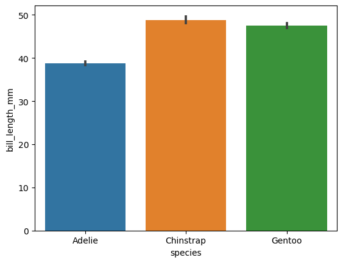

```python
sns.barplot(x="species", y="bill_length_mm", data=penguins)
```

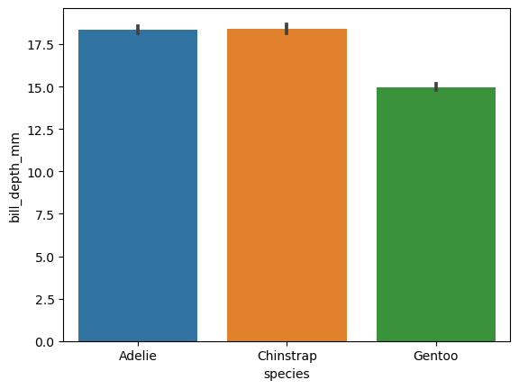

```python
sns.barplot(x="species", y="bill_depth_mm", data=penguins)
```

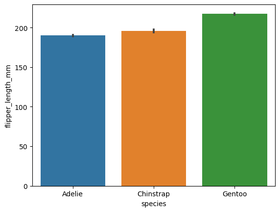

```python
sns.barplot(x="species", y="flipper_length_mm", data=penguins)
```

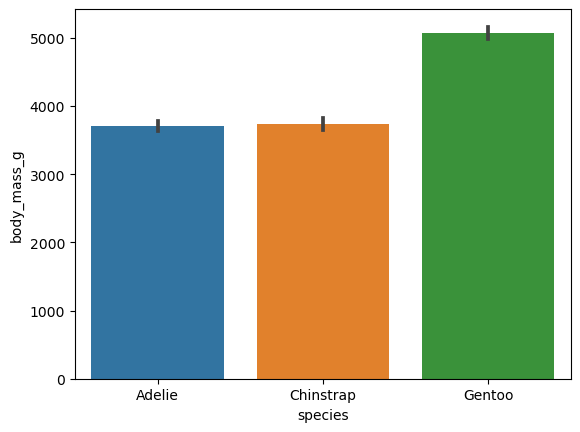

```python
sns.barplot(x="species", y="body_mass_g", data=penguins)
```

## (2/3) Categorie: Island

Hieronder staan alle barplots voor alle numerieke waardes en de verschillende eiland met pinguins.

De pinguins in Torgersen hebben minder bill_length. Op het Biscoe eiland hebben de pinguins minder bill_depth dan de rest. En de flipper lengte en de body mass is allebei groter op het Biscoe eiland.

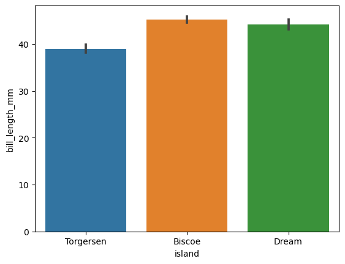

```python
sns.barplot(x="island", y="bill_length_mm", data=penguins)
```

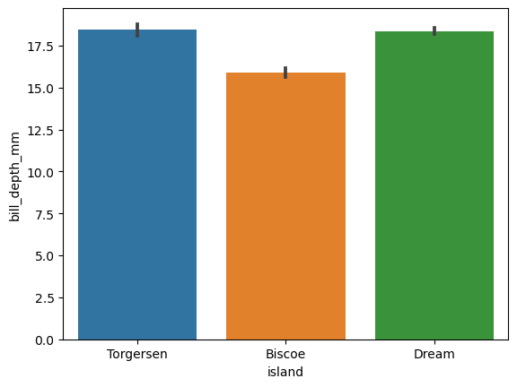

```python
sns.barplot(x="island", y="bill_depth_mm", data=penguins)
```

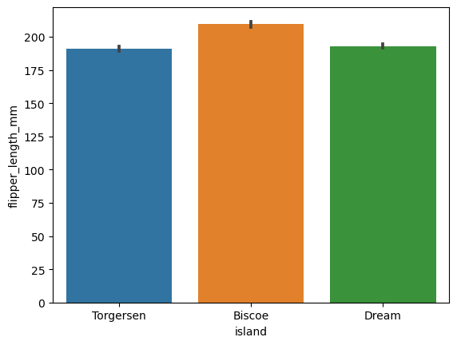

```python
sns.barplot(x="island", y="flipper_length_mm", data=penguins)
```

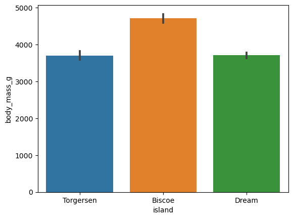

```python
sns.barplot(x="island", y="body_mass_g", data=penguins)
```

## (3/3) Categorie: Sex

Hieronder staan alle barplots voor alle numerieke waardes en de mannetjes of vrouwtjes pinguins.

In de barplots is te zien dat alle mannetjes pinguins op alle waardes hoger uitkomen dan de vrouwtjes. Met bill_length, bill_depth, flipper_length en body mass.

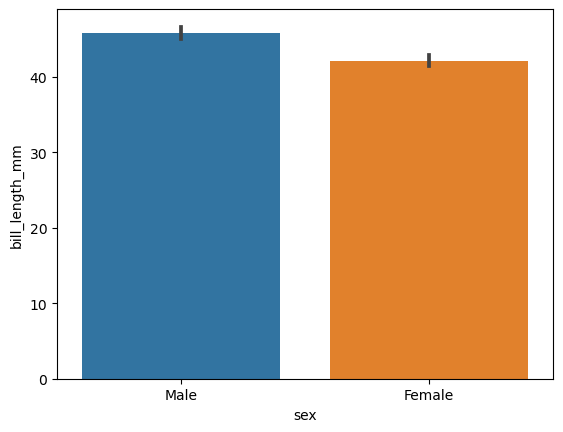

```python
sns.barplot(x="sex", y="bill_length_mm", data=penguins)
```

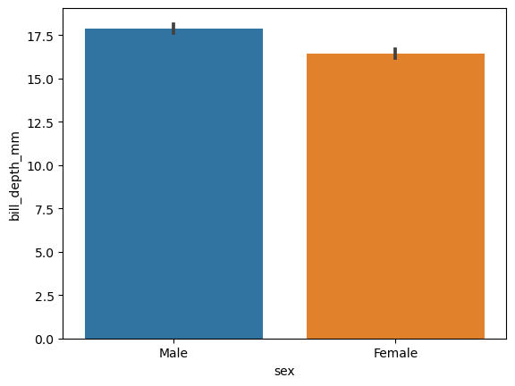

```python
sns.barplot(x="sex", y="bill_depth_mm", data=penguins)
```

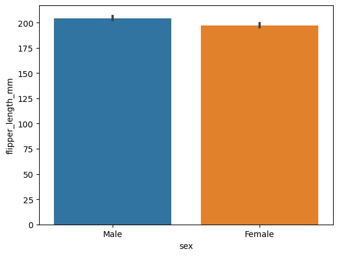

```python
sns.barplot(x="sex", y="flipper_length_mm", data=penguins)
```

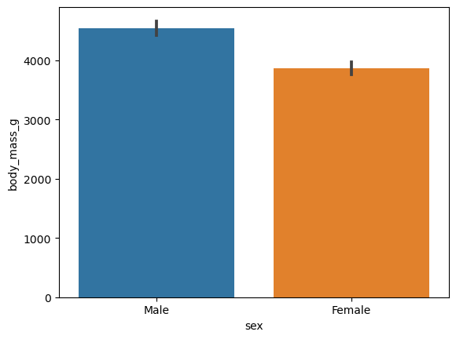

```python
sns.barplot(x="sex", y="body_mass_g", data=penguins)
```